# INFSCI 2595 Final Project

Part 4B, Interpretation - Customers

Zhenyu Li

2022-04-25

```r
library(tidyverse)
theme_set(theme_linedraw())
library(tidymodels)
tidymodels_prefer()
library(vip)
source("./scripts/utils.R")
```

```r
df <- readr::read_csv("./data/final_project_train.csv", col_names = TRUE)
df_regr <- df %>% select(-c(rowid,outcome)) %>% mutate(response = log(response))
df_clas <- df %>% select(-c(rowid,response))
```

Tasks

- Identify the customers appears to be hardest to predict for the regression and classification tasks
- Base your conclusions on the best performing regression and classification models.

## Hard to Predict Customer

The best model for the **regression task** was identified in part 2D4 as the Elastic Net model.  
The best model for the **classification task** was identified in part 3D4 as the Elastic Net model.

**Read in the respective best model for each task.**

```r
mod_regr <- readr::read_rds("./models/mod_2D_enet_best_wflow")
mod_regr_resample <- readr::read_rds("./models/mod_2D_enet_best_resample")

mod_clas <- readr::read_rds("./models/mod_3D_enet_best_wflow")
mod_clas_resample <- readr::read_rds("./models/mod_3D_enet_best_resample")
```

- To find the most unpredictable customer, need to visualize the prediction with regard to each customer.
- The respective resampled predictions are saved in the model resample files, and will be used for model evaluation.

## Regression

**Summarize the prediction error (MAE) across the resample repeated folds for each customer.**

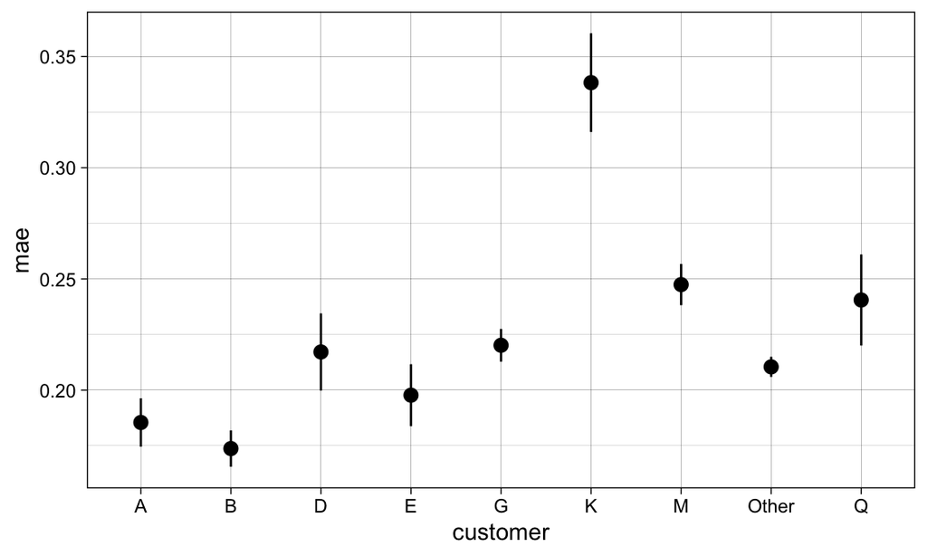

```r
regr_pred <- mod_regr_resample %>%
  # get all predictions across folds and repeats
  collect_predictions() %>%
  # join the training df
  left_join(rowid_to_column(select(df_regr,-response)), by = c(".row" = "rowid"))

regr_pred %>%
  group_by(id, id2, customer) %>%
  mae(response, .pred) %>%
  group_by(customer) %>%
  summarise(mae = mean(.estimate), mae_se = se(.estimate)) %>%
  ggplot() +
  geom_pointrange(aes(
    x=customer,
    y=mae,
    ymax=mae + mae_se,
    ymin = mae - mae_se,
    ))
```

- The `response` from customer K is the most difficult to predict using my best regression model.

## Classification

**Generate the ROC curve for each customer to visualize model performance.**

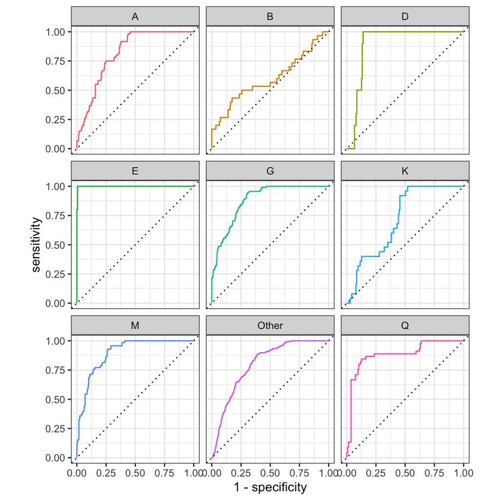

```r
clas_pred <- mod_clas_resample %>%
  collect_predictions(parameters = mod_clas$param) %>%
  left_join(rowid_to_column(select(df_clas,-outcome)), by = c(".row" = "rowid"))

clas_pred %>%
  group_by(customer) %>%
  roc_curve(outcome, .pred_event) %>%
  autoplot() + facet_wrap(~ customer) +
  theme(legend.position = "none")
```

**Examine observed event probability per customer.**

```r
df_clas %>% select(customer, outcome) %>%
  mutate(outcome = ifelse(outcome == "event",1,0)) %>%
  group_by(customer) %>%
  summarize(event_prob = sum(outcome)/length(outcome)) %>% knitr::kable(align = "c")
```

| customer | event_prob |
| --- | --- |
| A | 0.2181818 |
| B | 0.1153846 |
| D | 0.0625000 |
| E | 0.0285714 |
| G | 0.2035398 |
| K | 0.1315789 |
| M | 0.1971831 |
| Other | 0.2244898 |
| Q | 0.2500000 |

- As mentioned earlier in 4D1, ROC is not representative of model behavior since we have unbalanced events. This problem is exaggerated by splitting the observations further by `customer`. As shown by the extreme “good” performance for customers D, E, and the extreme “bad” performance for customer B, are both artifacts of the extreme skewed event probabilities of respective customer groups.

**Summarize the mean log loss across the resample repeated folds for each customer.**

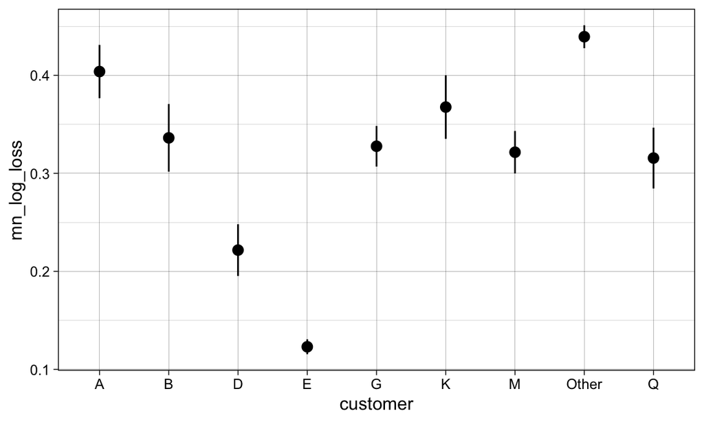

```r
clas_pred %>%
  group_by(id, id2, customer) %>%
  mn_log_loss(outcome, .pred_event) %>%
  group_by(customer) %>%
  summarise(mn_log_loss = mean(.estimate), se = se(.estimate)) %>%
  ggplot() +
  geom_pointrange(aes(
    x=customer,
    y=mn_log_loss,
    ymax=mn_log_loss + se,
    ymin = mn_log_loss - se,
    ))
```

- The `outcome` from customer `Other` appears to be the most difficult to predict using my best classification model. Because it is a pooled set, the next hard to predict customer is customer `A`.